# OOPs_2

#### Differences between Methods and Constructors:

Method

1. Method can be any name
2. It will be executed if we call that method
3. For an object, method can be called any number of times.
4. Method contains business logic

Constructor

1. Name should be always **init**
2. It will be executed automatically at the time of object creation.
3. For object, Constructor will be executed one-time
4. Constructor Inside we have to declare, initialize instance variables

```python
class Hello():
    def __init__(self):
        print('No Arg Passed')
    def __init__(self,x):
        print('One Arg Passed')

hh = Hello()
```

```
---------------------------------------------------------------------------
TypeError                                 Traceback (most recent call last)
<ipython-input-1-a0380c5f625e> in <module>
      5         print('One Arg Passed')
      6
----> 7 hh = Hello()

TypeError: __init__() missing 1 required positional argument: 'x'
```

```python
class Hello():
    def __init__(self):
        print('No Arg Passed')
    def __init__(self,x):
        print('One Arg Passed')

hh = Hello(1)
```

```
One Arg Passed
```

```python
class Hello():
    def __init__(self,x,y):
        print('No Arg Passed')
    def __init__(self,x):
        print('One Arg Passed')
    def __init__(self):
        print('One Arg Passed')

hh = Hello(1,1)
```

```
---------------------------------------------------------------------------
TypeError                                 Traceback (most recent call last)
<ipython-input-3-25ec726ab4c8> in <module>
      7         print('One Arg Passed')
      8
----> 9 hh = Hello(1,1)

TypeError: __init__() takes 1 positional argument but 3 were given
```

### In Python class we can represent data by using the following variables.

```
1.Instance Variables (Object Level Variables)
2.Static Variables (Class Level Variables)
3.Local variables (Method Level Variables)
```

Instance Variables: If the value of a variable is varied from object to object, for every object a separate copy of instance variables will be created.

Where we can declare Instance Variables:

1. Inside Constructor by using self variable
2. Inside Instance Method by using self variable
3. Outside of the class by using object reference variable

```python
class Emp():
    def __init__(self):
        """Instance variable list"""
        self.eid = 1
        self.ename = "Rakesh"
        self.esal = "$98000"

eDetails = Emp()
print(eDetails.__dict__)
```

```
{'eid': 1, 'ename': 'Rakesh', 'esal': '$98000'}
```

```python
class MyClass():
    #instance variable
    def __init__(self):
        self.x = 100
    #instance variable
    def MyMethod(self):
        self.y = 200
MM = MyClass()
MM.MyMethod()
#Outside of the class by using object reference variable
MM.z=300
print(MM.__dict__)
```

```
{'x': 100, 'y': 200, 'z': 300}
```

```python
class MyClass():
    #instance variable
    def __init__(self):
        self.x = 100
    #instance variable
    def MyMethod(self):
        self.x = 400
        self.y = 200
        del self.x
MM = MyClass()
MM.MyMethod()
#Outside of the class by using object reference variable
MM.z=300
print(MM.__dict__)
```

```
{'y': 200, 'z': 300}
```

#### Static Variables:

The value of a variable is constant for every object Class having static variable, shared by all objects of that class. Access static variables by class name or object reference, recommended to use class name.

Instance Variable vs Static Variable:

In the case of instance variables for every object a seperate copy created in the case of static variables for total class only one copy created

```python
class MyClass():
    #static variable
    x = 1
    def __init__(self):
        #instance variable
        self.y = 2
"""by object we can acess instance variable but by class name we can acess class variable"""
MM1 = MyClass()
MM1.y = 222
MyClass.x = 444
MM2 = MyClass()
print(MM1.x,MM1.y)
print(MM2.x,MM2.y)
```

```
444 222
444 2
```

#### Various Places to declare Static Variables:

1. We can declare within the class directly
2. Inside constructor by using class name
3. Inside instance method by using class name
4. Inside classmethod by using either class name or cls variable
5. Inside static method by using class name
6. Outside of class using obj ref. or class name

```python
class MyClass():
    #we can declare within the class directly
    p = 1
    def __init__(self):
        #Inside constructor by using class name
        MyClass.q = 2

    def MyMethod(self):
        #Inside instance method by using class name
        MyClass.r=3

    @classmethod
    def ClassMethod(cls): #Decorator
        #Inside classmethod by using either class name or cls variable
        MyClass.s=4
        cls.t = 5

    @staticmethod
    def statMethod(): #Decorator
        #Inside static method by using class name
        MyClass.u=4

print(MyClass.__dict__) #class level only p =1
```

```
{'__module__': '__main__', 'p': 1, '__init__': <function MyClass.__init__ at 0x000001D4E1E07790>, 'MyMethod': <function MyClass.MyMethod at 0x000001D4E1E07160>, 'ClassMethod': <classmethod object at 0x000001D4E1C361F0>, 'statMethod': <staticmethod object at 0x000001D4E1DE9AF0>, '__dict__': <attribut…
```

```python
class MyClass():
    #we can declare within the class directly
    p = 1
    def __init__(self):
        #Inside constructor by using class name
        MyClass.q = 2

    def MyMethod(self):
        #Inside instance method by using class name
        MyClass.r=3

    @classmethod
    def ClassMethod(cls): #Decorator
        #Inside classmethod by using either class name or cls variable
        MyClass.s=4
        cls.t = 5

    @staticmethod
    def statMethod(): #Decorator
        #Inside static method by using class name
        MyClass.u=4

MM = MyClass()
print(MyClass.__dict__) #Now p =1, q = 2
```

```
{'__module__': '__main__', 'p': 1, '__init__': <function MyClass.__init__ at 0x000001D4E1E07C10>, 'MyMethod': <function MyClass.MyMethod at 0x000001D4E1E071F0>, 'ClassMethod': <classmethod object at 0x000001D4E1E0BDF0>, 'statMethod': <staticmethod object at 0x000001D4E1E0BFA0>, '__dict__': <attribut…
```

```python
class MyClass():
    #we can declare within the class directly
    p = 1
    def __init__(self):
        #Inside constructor by using class name
        MyClass.q = 2

    def MyMethod(self):
        #Inside instance method by using class name
        MyClass.r=3

    @classmethod
    def ClassMethod(cls): #Decorator
        #Inside classmethod by using either class name or cls variable
        MyClass.s=4
        cls.t = 5

    @staticmethod
    def statMethod(): #Decorator
        #Inside static method by using class name
        MyClass.u=4

MM = MyClass()
MM.MyMethod()
print(MyClass.__dict__) #Now p =1, q = 2, r=3
```

```
{'__module__': '__main__', 'p': 1, '__init__': <function MyClass.__init__ at 0x000001D4E1E073A0>, 'MyMethod': <function MyClass.MyMethod at 0x000001D4E1E079D0>, 'ClassMethod': <classmethod object at 0x000001D4E1E0B1F0>, 'statMethod': <staticmethod object at 0x000001D4E1E0B490>, '__dict__': <attribut…
```

```python
class MyClass():
    #we can declare within the class directly
    p = 1
    def __init__(self):
        #Inside constructor by using class name
        MyClass.q = 2

    def MyMethod(self):
        #Inside instance method by using class name
        MyClass.r=3

    @classmethod
    def ClassMethod(cls): #Decorator
        #Inside classmethod by using either class name or cls variable
        MyClass.s=4
        cls.t = 5

    @staticmethod
    def statMethod(): #Decorator
        #Inside static method by using class name
        MyClass.u=4

MM = MyClass()
MM.MyMethod()
MM.ClassMethod()
print(MyClass.__dict__) ##Now p =1, q = 2, r=3, s= 4, t= 5
```

```
{'__module__': '__main__', 'p': 1, '__init__': <function MyClass.__init__ at 0x000001D4E1E07160>, 'MyMethod': <function MyClass.MyMethod at 0x000001D4E1E07790>, 'ClassMethod': <classmethod object at 0x000001D4E1C13B20>, 'statMethod': <staticmethod object at 0x000001D4E1C133A0>, '__dict__': <attribut…
```

```python
class MyClass():
    #we can declare within the class directly
    p = 1
    def __init__(self):
        #Inside constructor by using class name
        MyClass.q = 2

    def MyMethod(self):
        #Inside instance method by using class name
        MyClass.r=3

    @classmethod
    def ClassMethod(cls): #Decorator
        #Inside classmethod by using either class name or cls variable
        MyClass.s=4
        cls.t = 5

    @staticmethod
    def statMethod(): #Decorator
        #Inside static method by using class name
        MyClass.u=4

MM = MyClass()
MM.MyMethod()
MM.ClassMethod()
MM.statMethod()
print(MyClass.__dict__) #Now p =1, q = 2, r=3, s= 4, t= 5, u= 4
```

```
{'__module__': '__main__', 'p': 1, '__init__': <function MyClass.__init__ at 0x000001D4E1CF0E50>, 'MyMethod': <function MyClass.MyMethod at 0x000001D4E1CF0CA0>, 'ClassMethod': <classmethod object at 0x000001D4E1E2F520>, 'statMethod': <staticmethod object at 0x000001D4E1E2F0A0>, '__dict__': <attribut…
```

```python
class MyClass():
    #we can declare within the class directly
    p = 1
    def __init__(self):
        #Inside constructor by using class name
        MyClass.q = 2

    def MyMethod(self):
        #Inside instance method by using class name
        MyClass.r=3

    @classmethod
    def ClassMethod(cls): #Decorator
        #Inside classmethod by using either class name or cls variable
        MyClass.s=4
        cls.t = 5

    @staticmethod
    def statMethod(): #Decorator
        #Inside static method by using class name
        MyClass.u=4

MM = MyClass()
MM.MyMethod()
MM.ClassMethod()
MM.statMethod()
#Outside of class using obj ref. or class name
MyClass.v = 7
print(MyClass.__dict__) #Now p =1, q = 2, r=3, s= 4, t= 5, u= 4, v=7
```

```
{'__module__': '__main__', 'p': 1, '__init__': <function MyClass.__init__ at 0x000001D4E1E15820>, 'MyMethod': <function MyClass.MyMethod at 0x000001D4E1E15790>, 'ClassMethod': <classmethod object at 0x000001D4E1E2FC40>, 'statMethod': <staticmethod object at 0x000001D4E1E2FBB0>, '__dict__': <attribut…
```

#### Local variables/Temporary variables (Method Level Variables):

1. If we can declare variables inside a method directly.
2. It will be created at the time of method execution
3. They destroyed once method execution completes.
4. They cannot be accessed from outside of method.

```python
class MyClass():
    def FirstMethod(self):
        #Local Variable
        x = 1
        print(x)
    def SecondMethod(self):
        #Local Variable
        y=2
        print(y)
MM = MyClass()
MM.FirstMethod()
MM.SecondMethod()
```

```
1
2
```

#### Attributes

An attribute is a specification that defines a property of an object, element, or file.  
It may also refer to or set the specific value for a given instance of such.

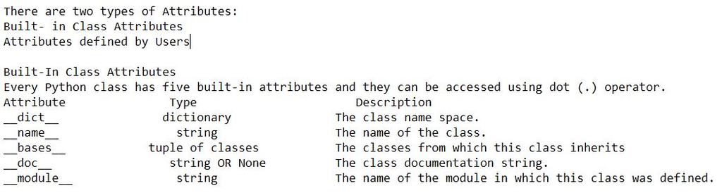

#### A. Built-in class attributes

```python
class MyBuiltinAttrs():
    pass
print(MyBuiltinAttrs.__dict__)
```

```
{'__module__': '__main__', '__dict__': <attribute '__dict__' of 'MyBuiltinAttrs' objects>, '__weakref__': <attribute '__weakref__' of 'MyBuiltinAttrs' objects>, '__doc__': None}
```

```python
print(MyBuiltinAttrs.__name__)
```

```
MyBuiltinAttrs
```

```python
print(MyBuiltinAttrs.__bases__)
```

```
(<class 'object'>,)
```

```python
print(MyBuiltinAttrs.__doc__)
```

```
None
```

```python
print(MyBuiltinAttrs.__module__)
```

```
__main__
```

#### B. Attribute defined by Users

1. Attributes are created inside the class definition
2. We can dynamically create new attributes for existing instances of a class
3. Attributes can be bound to class names as well

```python
class Student():
    #User defined Attribute
    StdNo = 1
#Using class Name
print(Student.StdNo)
#Creating instance or object
MyObj = Student()
#Display Using Instance or Object
print(MyObj.StdNo)
```

```
1
1
```

#### Access Modifiers

PYTHON supports the following list of Access Modifiers:

1. Public:Attributes can be freely used
2. Protected: (Restricted) attributes should only be used under certain conditions
3. Private:Attributes can only be accessed inside of the class definition

```python
"""
name   - public    - These attributes can be used freely inside or outside of a class definition
_name  - protected - These attributes should not be used outside of the class definition, unless inside of a subclass definition
__name - private   - This kind of attributes inaccessible and invisible.
"""
```

```python
class AccessModifiers():
    def __init__(self):
        self.x = "Hey I am Public Attribute"
        self._y = "Hey I am Protected Attribute"
        self.__Z = "Hey I am Private Attribute"

#Creating Object or Instance
AA = AccessModifiers()
#Calling the Attribute
print(AA.x)
print(AA._y)
print(AA.__z)
```

```
Hey I am Public Attribute
Hey I am Protected Attribute
```

```
---------------------------------------------------------------------------
AttributeError                            Traceback (most recent call last)
<ipython-input-5-b8d39c522b41> in <module>
     10 print(AA.x)
     11 print(AA._y)
---> 12 print(AA.__z)

AttributeError: 'AccessModifiers' object has no attribute '__z'
```

#### getattr

It returns the value of the named attribute of an object. If not found, it returns the default value provided to the function.

#### setattr

It sets the value of given attribute of an object.

#### hasattr

It returns true if an object has the given named attribute and false if it does not.

#### delattr

It deletes an attribute from the object (if the object allows it).

```python
class Banking():
    #User defined Attribute
    custid = 1001
    custname = "RKDas"

bb = Banking()
print(getattr(bb,'custid'))
print(getattr(bb,'custname'))
print(getattr(bb,'Loc','Hyderabad'))
```

```
1001
RKDas
Hyderabad
```

```python
print(getattr(bb,'custid',1002)) #This is the demerit. so use setattr
```

```
1001
```

```python
setattr(bb,'custid',1002)
print(getattr(bb,'custid'))
```

```
1002
```

```python
hasattr(bb,'custname')
```

```
True
```

```python
hasattr(bb,'Loc')
```

```
False
```

```python
hasattr(bb,'custid')
```

```
True
```

```python
bb.__dict__
```

```
{'custid': 1002}
```

```python
Banking.__dict__
```

```
mappingproxy({'__module__': '__main__',
              'custid': 1001,
              'custname': 'RKDas',
              '__dict__': <attribute '__dict__' of 'Banking' objects>,
              '__weakref__': <attribute '__weakref__' of 'Banking' objects>,
              '__doc__': None})
```

```python
delattr(bb,'custid')
```

```python
getattr(bb,'custid')
```

```
1001
```

```python
delattr(bb,'custid')
```

```
---------------------------------------------------------------------------
AttributeError                            Traceback (most recent call last)
<ipython-input-28-ead4df9f3eb7> in <module>
----> 1 delattr(bb,'custid')

AttributeError: custid
```